# Interactive Web-based Data Visualization (1)

CMSC320  
Spring 2016

*Politics*: http://www.nytimes.com/interactive/2012/11/02/us/politics/paths-to-the-white-house.html?_r=0

*Science*: http://epiviz.cbcb.umd.edu/?ws=YOsu0RmUc9l

*Movies*: http://www.nytimes.com/interactive/2013/02/20/movies/among-the-oscar-contenders-a-host-of-connections.html

*Sports*: http://fivethirtyeight.com/interactives/march-madness-predictions-2015/#mens

### Why Interactivity?

*Reduce data dimension*: allow user to explore large datasets by quickly switching between dimensions

*Overview first, zoom and filter, details on demand*: Provide big picture, let the user explore details as they desire

*Linked views for high dimensions*: There is a limit to the number of aesthetic mappings in a single graphic, make multiple graphics but link data objects between them

### Web-based interactive visualization

Take advantage of HTML document description and the [Document Object Model](http://www.w3.org/DOM/) interface to *bind* data to page elements.

- Shiny: bind data to controls
- Data-driven Documents (d3.js): bind data to svg elements directly

### HTML and DOM

Web pages are structured using Hypertext Markup Language

```html
<!DOCTYPE html>
<html>
  <head>
    <title>Page Title</title>
  </head>
  <body>
    <h1>Page Title</h1>
    <p>This is a really interesting paragraph.</p>
  </body>
</html>
```

Basic idea is to only specify *content* and *structure* but not specify directly *how* to render pages.

### HTML and DOM

Web pages are structured using Hypertext Markup Language

```html
<!DOCTYPE html>
<html>
  <head>
    <title>Page Title</title>
  </head>
  <body>
    <h1>Page Title</h1>
    <p>This is a really interesting paragraph.</p>
  </body>
</html>
```

Structure is provided by page *elements.* An important element we'll see later is the arbitrary grouping/containment element `div`.

### HTML and DOM

Web pages are structured using Hypertext Markup Language

```html
<!DOCTYPE html>
<html>
  <head>
    <title>Page Title</title>
  </head>
  <body>
    <h1>Page Title</h1>
    <p>This is a really interesting paragraph.</p>
  </body>
</html>
```

The hierarchical structure of elements in a document are defined by the *Document Object Model* (DOM).

### CSS

Cascading Style Sheets are used to style elements in the DOM.

```
body {
  background-color: white;
  color: black;
}
```

In general:

```
selectorA,
selectorB,
selectorC {
  property1: value;
  property2: value;
  property3: value;
}
```

### CSS

Selectors:

- Type selectors: match DOM elements by name

```
h1  /* select all level 1 headings */
p   /* select all paragraphs       */
div /* select all divs             */
```

### CSS

Selectors:

- Class selectors: match DOM elements assigned to a specified class.

```
<p class="alert">You are about to become interactive</p>
<p>But you are not</p>
```

```
.alert {
  background-color: red;
  color: white;
}
```

### SVG

Scalable Vector Graphics (SVG) is special element used to create graphics with text.

```
<svg width="50" height="50">
  <circle cx="25" cy="25" r="22" fill="blue" stroke="gray" stroke-width="2"/>
</svg>
```

### SVG

Elements have *geometric* attributes and *style* attributes.

```
<circle cx="250" cy="25" r="25"/>
```

`cx`: x-coordinate of circle center  
`cy`: y-coordinate of circle center  
`r`: radius of circle

### SVG

Elements have *geometric* attributes and *style* attributes.

```
<rect x="0" y="0" width="500" height="50"/>
```

`x`: x-coordinate of left-top corner  
`y`: y-coordinate of left-top corner  
`width`, `height`: width and height of rectangle

### SVG

*style* attributes

```
<circle cx="25" cy="25" r="22" fill="yellow" stroke="orange" stroke-width="5"/>
```

can be styled by class as well

```
svg .pumpkin {
  fill: yellow;
  stroke: orange;
  stroke-width: 5;
}
```

```
<circle cx="25" cy="25" r="22" class="pumpkin">
```

### Shiny and D3

Shiny: construct DOM and bind data (variables for example) to elements (a slide control for example)

D3: bind data to SVG element attributes (position, size, color, transparency, etc.)

### Reactivity

Interactivity and binding in Shiny achieved using *reactive programming*. Where objects *react* to changes in other objects.

### Reactivity

Example:

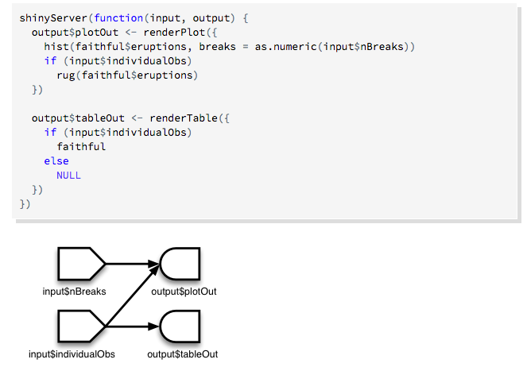

### Reactivity

With intermediate objects:

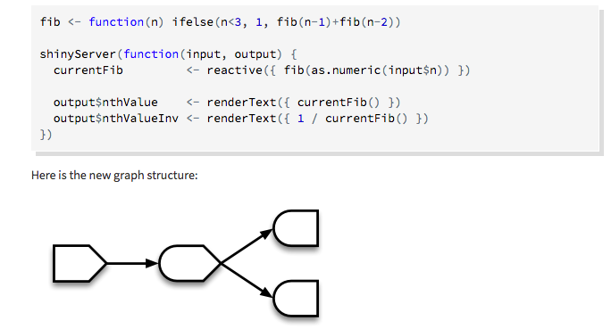

### Reactivity

A standard paradigm for interactive (event-driven) application development

A nice review paper: http://dl.acm.org/citation.cfm?id=2501666

### Binding data to graphical elements

So far, we have bound data objects to document elements.  
More examples: http://shiny.rstudio.com/gallery/

Next time we bind data directly to *graphical* elements

- since using SVG these are also document elements (D3).